# Compute Index Values

## Disclaimer

This notebook contains a few tests about how to compute an index for a set of animals.

## Small Example Dataset

Given are a dataframe of animals with their breeding values. A small example data frame would look as follows. We start by reading the small dataset with estimated breeding values.

```r
s_lm_sfa_fn <- "first100_LM_cfa.txt"
df_lm_cfa <- read.table(file = s_lm_sfa_fn, header = TRUE, stringsAsFactors = FALSE)
str(df_lm_cfa)
```

```
## 'data.frame':    99 obs. of  14 variables:
##  $ idaTvd   : chr  "CH120109208465" "CH120071583461" "CH120069628679" "CH120066597954" ...
##  $ trait    : chr  "cfa" "cfa" "cfa" "cfa" ...
##  $ nDau     : int  21 22 22 21 24 83 4678 46 44 21 ...
##  $ nHerd    : int  1 5 1 1 4 71 2110 37 39 8 ...
##  $ estimate : num  79.4 93.4 93.2 85.3 81 ...
##  $ rel      : num  0.77 0.78 0.77 0.77 0.79 0.93 0.99 0.88 0.95 0.89 ...
##  $ type     : chr  "P" "P" "P" "P" ...
##  $ label    : chr  "CH" "CH" "CH" "CH" ...
##  $ pubCode  : chr  "Y" "Y" "Y" "Y" ...
##  $ base     : chr  "LM18" "LM18" "LM18" "LM18" ...
##  $ idaItb   : chr  "LMCHEM120109208465" "LMCHEM120071583461" "LMCHEM120069628679" "LMCHEM120066597954" ...
##  $ birthdate: int  2014 2008 2008 2007 2012 1988 1988 1990 1991 1991 ...
##  $ breed    : chr  "LM" "LM" "LM" "LM" ...
##  $ sex      : chr  "M" "M" "M" "M" ...
```

Conversion to `tibble`

```r
tbl_lm_cfa <- dplyr::as_tibble(df_lm_cfa)
tbl_lm_cfa
```

| idaTvd | trait | nDau | nHerd | estimate | rel | type | label | pubCode | base | idaItb | birthdate | breed | sex |
| --- | --- | --- | --- | --- | --- | --- | --- | --- | --- | --- | --- | --- | --- |
| CH120109208465 | cfa | 21 | 1 | 79.37 | 0.77 | P | CH | Y | LM18 | LMCHEM120109208465 | 2014 | LM | M |
| CH120071583461 | cfa | 22 | 5 | 93.37 | 0.78 | P | CH | Y | LM18 | LMCHEM120071583461 | 2008 | LM | M |
| CH120069628679 | cfa | 22 | 1 | 93.22 | 0.77 | P | CH | Y | LM18 | LMCHEM120069628679 | 2008 | LM | M |
| CH120066597954 | cfa | 21 | 1 | 85.26 | 0.77 | P | CH | Y | LM18 | LMCHEM120066597954 | 2007 | LM | M |
| CH120098006004 | cfa | 24 | 4 | 81.02 | 0.79 | P | CH | Y | LM18 | LMCHEM120098006004 | 2012 | LM | M |
| CH900000281657 | cfa | 83 | 71 | 100.75 | 0.93 | P | CH | Y | LM18 | LMCHEM900000281657 | 1988 | LM | M |
| CH900000281633 | cfa | 4678 | 2110 | 110.66 | 0.99 | P | CH | Y | LM18 | LMCHEM900000281633 | 1988 | LM | M |
| CZ303050019912 | cfa | 46 | 37 | 106.41 | 0.88 | P | CH | Y | LM18 | LMCZEM030305001991 | 1990 | LM | M |
| FR087910026040 | cfa | 44 | 39 | 87.93 | 0.95 | P | CH | Y | LM18 | LMFRAM008791002604 | 1991 | LM | M |
| FR087910505057 | cfa | 21 | 8 | 101.01 | 0.89 | P | CH | Y | LM18 | LMFRAM900090553350 | 1991 | LM | M |

[output cut: 89 more lines]

## Convert File Names To Trait Names

We define the following function to extract trait names from input file names.

```r
get_trait_name <- function(ps_file_name){
  # split input file name with "_" and keep the last element
  s_trait_result <- unlist(strsplit(ps_file_name, split = "_", fixed = TRUE))
  s_trait_result <- s_trait_result[length(s_trait_result)]
  # split result with "." and keep the first element
  s_trait_result <- unlist(strsplit(s_trait_result, split = ".", fixed = TRUE))
  s_trait_result <- s_trait_result[1]
  return(s_trait_result)
}
get_trait_name(ps_file_name = s_lm_sfa_fn)
```

```
## [1] "cfa"
```

Reading more breeding values

```r
library(dplyr)
s_lm_pat <- "first100_LM"
vec_lm_fn <- list.files(pattern = s_lm_pat)

tbl_result <- NULL
### # loop and aggregate
for (f in seq_along(vec_lm_fn)){
  # f <- 1
  s_current_fn <- vec_lm_fn[f]
  cat("Reading file: ", s_current_fn, "\n")
  s_trait_name <- get_trait_name(ps_file_name = s_current_fn)

  # reading the predicted breeding values for the current file
  tbl_current <- readr::read_delim(file = vec_lm_fn[f], delim = " ")
  # select columns tvd-nr and estimate
  tbl_current <- tbl_current %>% select(idaTvd, estimate)
  if(is.null(tbl_result)){
    tbl_result <- tbl_current
    names(tbl_result) <- c("idaTvd", s_trait_name)
  } else {
    tbl_result <- tbl_result %>% inner_join(tbl_current, by = "idaTvd")
    names(tbl_result) <- c(names(tbl_result)[1:(ncol(tbl_result)-1)], s_trait_name)
  }

}
```

```
## Reading file:  first100_LM_cca.txt
```

```
## Reading file:  first100_LM_cfa.txt
```

```
## Reading file:  first100_LM_cwa.txt
```

```r
tbl_result
```

| idaTvd | cca | cfa | cwa |
| --- | --- | --- | --- |
| CH120109208465 | 112.52 | 79.37 | 124.42 |
| CH120071583461 | 101.94 | 93.37 | 90.81 |
| CH120069628679 | 104.62 | 93.22 | 129.88 |
| CH120066597954 | 101.72 | 85.26 | 104.44 |
| CH120098006004 | 108.90 | 81.02 | 113.77 |
| CH900000281657 | 115.05 | 100.75 | 103.71 |
| CH900000281633 | 101.67 | 110.66 | 102.16 |
| CZ303050019912 | 102.96 | 106.41 | 105.86 |
| FR087910026040 | 105.98 | 87.93 | 96.80 |
| FR087910505057 | 106.83 | 101.01 | 116.89 |

[output cut: 89 more lines]

## Re-arrange Data using `gather()`

We use the gather function to re-arrange the data. What `gather()` does is shown in the following figure

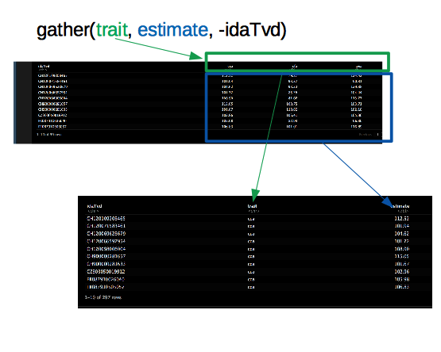

The above shown call does the following

```r
library(tidyr)
gatbl_result <- tbl_result %>%
  gather(trait, estimate, -idaTvd)
gatbl_result
```

| idaTvd | trait | estimate |
| --- | --- | --- |
| CH120109208465 | cca | 112.52 |
| CH120071583461 | cca | 101.94 |
| CH120069628679 | cca | 104.62 |
| CH120066597954 | cca | 101.72 |
| CH120098006004 | cca | 108.90 |
| CH900000281657 | cca | 115.05 |
| CH900000281633 | cca | 101.67 |
| CZ303050019912 | cca | 102.96 |
| FR087910026040 | cca | 105.98 |
| FR087910505057 | cca | 106.83 |

[output cut: 287 more lines]

## Economic Values

Vectors of economic values are computed elsewhere and are taken as given here. To begin with we have a vector with those values as input.

```r
vec_ev <- c(0.002097717, 0.001566957, 1.415233)
```

The vector is augmented with the trait names and is integrated into a new `tibble`

```r
tbl_ev <- tibble(trait = c("cca", "cfa", "cwa"), ev=vec_ev)
tbl_ev
```

| trait | ev |
| --- | --- |
| cca | 0.002097717 |
| cfa | 0.001566957 |
| cwa | 1.415233000 |

## Resources

We start with a few experiments from https://stackoverflow.com/questions/41247487/product-of-several-columns-on-a-data-frame-by-a-vector-using-dplyr

```r
tbl <- tibble::data_frame(
  letters = c("A", "B", "C", "D"),
  col1 = c(3, 3, 2, 3),
  col2 = c(2, 2, 3, 1),
  col3 = c(4, 1, 1, 3)
)
tbl
```

| letters | col1 | col2 | col3 |
| --- | --- | --- | --- |
| A | 3 | 2 | 4 |
| B | 3 | 2 | 1 |
| C | 2 | 3 | 1 |
| D | 3 | 1 | 3 |

Then we define a weight

```r
vec_weigth <- c(1:3)
```

First look at demo of `tidyr::so-17481212`.

```r
demo(tidyr::so-17481212)
```

Unroll the the single steps into

```r
library(tidyr)
library(dplyr)
race <- read.table(header = TRUE, check.names = FALSE, text = "
Name    50  100  150  200  250  300  350
Carla  1.2  1.8  2.2  2.3  3.0  2.5  1.8
Mace   1.5  1.1  1.9  2.0  3.6  3.0  2.5
Lea    1.7  1.6  2.3  2.7  2.6  2.2  2.6
Karen  1.3  1.7  1.9  2.2  3.2  1.5  1.9")
race
```

| Name | 50 | 100 | 150 | 200 | 250 | 300 | 350 |
| --- | --- | --- | --- | --- | --- | --- | --- |
| Carla | 1.2 | 1.8 | 2.2 | 2.3 | 3.0 | 2.5 | 1.8 |
| Mace | 1.5 | 1.1 | 1.9 | 2.0 | 3.6 | 3.0 | 2.5 |
| Lea | 1.7 | 1.6 | 2.3 | 2.7 | 2.6 | 2.2 | 2.6 |
| Karen | 1.3 | 1.7 | 1.9 | 2.2 | 3.2 | 1.5 | 1.9 |

First, we do a `gather()`-step

```r
race %>%
   gather(Time, Score, -Name, convert = TRUE)
```

| Name | Time | Score |
| --- | --- | --- |
| Carla | 50 | 1.2 |
| Mace | 50 | 1.5 |
| Lea | 50 | 1.7 |
| Karen | 50 | 1.3 |
| Carla | 100 | 1.8 |
| Mace | 100 | 1.1 |
| Lea | 100 | 1.6 |
| Karen | 100 | 1.7 |
| Carla | 150 | 2.2 |
| Mace | 150 | 1.9 |

[output cut: 18 more lines]

Add a step using the `arrange()` function.

```r
race %>%
   gather(Time, Score, -Name, convert = TRUE) %>%
   arrange(Name, Time)
```

| Name | Time | Score |
| --- | --- | --- |
| Carla | 50 | 1.2 |
| Carla | 100 | 1.8 |
| Carla | 150 | 2.2 |
| Carla | 200 | 2.3 |
| Carla | 250 | 3.0 |
| Carla | 300 | 2.5 |
| Carla | 350 | 1.8 |
| Karen | 50 | 1.3 |
| Karen | 100 | 1.7 |
| Karen | 150 | 1.9 |

[output cut: 18 more lines]

```r
tmp <- tbl %>%
  gather(variable, value, -letters) %>%
  group_by(letters) %>%
  mutate(value = value * vec_weigth) %>%
  spread(variable, value)
tmp
```

| letters | col1 | col2 | col3 |
| --- | --- | --- | --- |
| A | 3 | 4 | 12 |
| B | 3 | 4 | 3 |
| C | 2 | 6 | 3 |
| D | 3 | 2 | 9 |

How can we compute the sum of the numeric columns

```r
tmp %>%
  as.matrix()
```

```
##      letters col1 col2 col3
## [1,] "A"     "3"  "4"  "12"
## [2,] "B"     "3"  "4"  " 3"
## [3,] "C"     "2"  "6"  " 3"
## [4,] "D"     "3"  "2"  " 9"
```

```r
iris %>%
  mutate(sumVar = select(., contains("Sepal")) %>% rowSums()) %>%
  head
```

|  | Sepal.Length | Sepal.Width | Petal.Length | Petal.Width | Species | sumVar |
| --- | --- | --- | --- | --- | --- | --- |
| 1 | 5.1 | 3.5 | 1.4 | 0.2 | setosa | 8.6 |
| 2 | 4.9 | 3.0 | 1.4 | 0.2 | setosa | 7.9 |
| 3 | 4.7 | 3.2 | 1.3 | 0.2 | setosa | 7.9 |
| 4 | 4.6 | 3.1 | 1.5 | 0.2 | setosa | 7.7 |
| 5 | 5.0 | 3.6 | 1.4 | 0.2 | setosa | 8.6 |
| 6 | 5.4 | 3.9 | 1.7 | 0.4 | setosa | 9.3 |

## Functional Programming

Try to use the `purrr::map()`-function for an example given at: https://campus.datacamp.com/courses/writing-functions-in-r/functional-programming?ex=1

```r
library(purrr)
(means <- map_dbl(mtcars, mean))
```

```
##        mpg        cyl       disp         hp       drat         wt
##  20.090625   6.187500 230.721875 146.687500   3.596563   3.217250
##       qsec         vs         am       gear       carb
##  17.848750   0.437500   0.406250   3.687500   2.812500
```

```r
(medians <- map_dbl(mtcars, median))
```

```
##     mpg     cyl    disp      hp    drat      wt    qsec      vs      am
##  19.200   6.000 196.300 123.000   3.695   3.325  17.710   0.000   0.000
##    gear    carb
##   4.000   2.000
```

## `gather`-Function

Based on https://www.rdocumentation.org/packages/tidyr/versions/0.8.1/topics/gather an example that shows the gather function

```r
n_nr_stocks <- 4
library(dplyr)
# From http://stackoverflow.com/questions/1181060
stocks <- tibble(
  time = as.Date('2009-01-01') + 0:(n_nr_stocks-1),
  X = rnorm(n_nr_stocks, 0, 1),
  Y = rnorm(n_nr_stocks, 0, 2),
  Z = rnorm(n_nr_stocks, 0, 4)
)
stocks
```

| time | X | Y | Z |
| --- | --- | --- | --- |
| 2009-01-01 | -0.2593567 | -0.7109794 | 5.070838 |
| 2009-01-02 | 1.7538686 | -4.5548515 | 4.730113 |
| 2009-01-03 | -0.2464815 | -1.4835010 | 2.359608 |
| 2009-01-04 | 0.2482911 | 2.6706065 | -6.930003 |

Using the `gather()`-function

```r
stocks %>% gather(stock, price, -time)
```

| time | stock | price |
| --- | --- | --- |
| 2009-01-01 | X | -0.2593567 |
| 2009-01-02 | X | 1.7538686 |
| 2009-01-03 | X | -0.2464815 |
| 2009-01-04 | X | 0.2482911 |
| 2009-01-01 | Y | -0.7109794 |
| 2009-01-02 | Y | -4.5548515 |
| 2009-01-03 | Y | -1.4835010 |
| 2009-01-04 | Y | 2.6706065 |
| 2009-01-01 | Z | 5.0708378 |
| 2009-01-02 | Z | 4.7301127 |

[output cut: 2 more lines]

The `gather()`-function does a special sort of un-folding a dataframe. The result of the `gather()`-function is a new dataframe. The first argument to the `gather()`-function is the column that contains the names of the original dataframe. The second arugment is the values of the original dataframe. All arguments with a minus in front of them are not unfolded.